# Tidyverse

#### 4. Grouping and summarizing!

Summarizing data in columns is achieved like so:

```r
# mean manufacturing year:
mpg %>%
  summarise(mean=mean(year))
```

```
## # A tibble: 1 × 1
##    mean
##   <dbl>
## 1 2004.
```

```r
# it is much more powerful however... we could for example:

# get the means of all numeric variables
mpg %>%
  summarise_if(is.numeric, mean)
```

```
## # A tibble: 1 × 6
##   displ  year   cyl   cty   hwy avg_consumption
##   <dbl> <dbl> <dbl> <dbl> <dbl>           <dbl>
## 1  3.47 2004.  5.89  16.9  23.4            20.1
```

```r
# or get multiple summary statistics at once:

mpg %>%
  summarise(mean_cty=mean(cty),
            sd_cty=sd(cty))
```

```
## # A tibble: 1 × 2
##   mean_cty sd_cty
##      <dbl>  <dbl>
## 1     16.9   4.26
```

This function is really useful when you combine it with `group_by()`. This does exactly what it says on the box: it groups data by a specified variable:

```r
# look what happens when we group by manufacturer:
mpg %>%
  group_by(manufacturer)
```

```
## # A tibble: 234 × 12
## # Groups:   manufacturer [15]
##    manufacturer model      displ  year   cyl trans drv     cty   hwy fl    class
##    <chr>        <chr>      <dbl> <int> <int> <chr> <chr> <int> <int> <chr> <chr>
##  1 audi         a4           1.8  1999     4 auto… f        18    29 p     comp…
##  2 audi         a4           1.8  1999     4 manu… f        21    29 p     comp…
##  3 audi         a4           2    2008     4 manu… f        20    31 p     comp…
##  4 audi         a4           2    2008     4 auto… f        21    30 p     comp…
##  5 audi         a4           2.8  1999     6 auto… f        16    26 p     comp…
##  6 audi         a4           2.8  1999     6 manu… f        18    26 p     comp…
##  7 audi         a4           3.1  2008     6 auto… f        18    27 p     comp…
##  8 audi         a4 quattro   1.8  1999     4 manu… 4        18    26 p     comp…
##  9 audi         a4 quattro   1.8  1999     4 auto… 4        16    25 p     comp…
## 10 audi         a4 quattro   2    2008     4 manu… 4        20    28 p     comp…
## # ℹ 224 more rows
## # ℹ 1 more variable: avg_consumption <dbl>
```

```r
## you should see that the table header now contains the grouping information (manufacturer[15])

# and now, we can get summary statistics per group:
mpg %>%
  group_by(manufacturer) %>%
  summarise_if(is.numeric, .funs = c(mean=mean, sd=sd))
```

```
## # A tibble: 15 × 13
##    manufacturer displ_mean year_mean cyl_mean cty_mean hwy_mean
##    <chr>             <dbl>     <dbl>    <dbl>    <dbl>    <dbl>
##  1 audi               2.54     2004.     5.22     17.6     26.4
##  2 chevrolet          5.06     2005.     7.26     15       21.9
##  3 dodge              4.38     2004.     7.08     13.1     17.9
##  4 ford               4.54     2003.     7.2      14       19.4
##  5 honda              1.71     2003      4        24.4     32.6
##  6 hyundai            2.43     2004.     4.86     18.6     26.9
##  7 jeep               4.58     2006.     7.25     13.5     17.6
##  8 land rover         4.3      2004.     8        11.5     16.5
##  9 lincoln            5.4      2002      8        11.3     17
## 10 mercury            4.4      2004.     7        13.2     18
## 11 nissan             3.27     2004.     5.54     18.1     24.6
## 12 pontiac            3.96     2003.     6.4      17       26.4
## 13 subaru             2.46     2004.     4        19.3     25.6
## 14 toyota             2.95     2003.     5.12     18.5     24.9
## 15 volkswagen         2.26     2003.     4.59     20.9     29.2
## # ℹ 7 more variables: avg_consumption_mean <dbl>, displ_sd <dbl>,
## #   year_sd <dbl>, cyl_sd <dbl>, cty_sd <dbl>, hwy_sd <dbl>,
## #   avg_consumption_sd <dbl>
```

5. left join, right join, inner join, full join!

Any SQL people out there? Often, we have more than one dataset or table and we want to join them based on a reference variable. These "join" operations can go in different directions, depending on which table you want to complete:

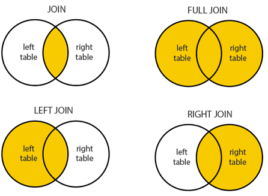

You will most likely use `left_join()` most, where you wish to pull additional data from a second table into your first/primary table

```r
# imagine the mpg data set was our most complete data set, but we were working with a list of only manual cars and their manufacturing details, and we wanted to find out what millage these cars have:

# our manual data subset
df1<-mpg %>%
  select(-c(cty, hwy)) %>%
  filter(str_detect(trans, "manual"))
df1
```

```
## # A tibble: 77 × 10
##    manufacturer model  displ  year   cyl trans drv   fl    class avg_consumption
##    <chr>        <chr>  <dbl> <int> <int> <chr> <chr> <chr> <chr>           <dbl>
##  1 audi         a4       1.8  1999     4 manu… f     p     comp…            25
##  2 audi         a4       2    2008     4 manu… f     p     comp…            25.5
##  3 audi         a4       2.8  1999     6 manu… f     p     comp…            22
##  4 audi         a4 qu…   1.8  1999     4 manu… 4     p     comp…            22
##  5 audi         a4 qu…   2    2008     4 manu… 4     p     comp…            24
##  6 audi         a4 qu…   2.8  1999     6 manu… 4     p     comp…            21
##  7 audi         a4 qu…   3.1  2008     6 manu… 4     p     comp…            20
##  8 chevrolet    corve…   5.7  1999     8 manu… r     p     2sea…            21
##  9 chevrolet    corve…   6.2  2008     8 manu… r     p     2sea…            21
## 10 chevrolet    corve…   7    2008     8 manu… r     p     2sea…            19.5
## # ℹ 67 more rows
```

```r
# now we can join the two, to get the millage information for just these manual cars
df1 %>%
  left_join(mpg)
```

```
## # A tibble: 79 × 12
##    manufacturer model  displ  year   cyl trans drv   fl    class avg_consumption
##    <chr>        <chr>  <dbl> <int> <int> <chr> <chr> <chr> <chr>           <dbl>
##  1 audi         a4       1.8  1999     4 manu… f     p     comp…            25
##  2 audi         a4       2    2008     4 manu… f     p     comp…            25.5
##  3 audi         a4       2.8  1999     6 manu… f     p     comp…            22
##  4 audi         a4 qu…   1.8  1999     4 manu… 4     p     comp…            22
##  5 audi         a4 qu…   2    2008     4 manu… 4     p     comp…            24
##  6 audi         a4 qu…   2.8  1999     6 manu… 4     p     comp…            21
##  7 audi         a4 qu…   3.1  2008     6 manu… 4     p     comp…            20
##  8 chevrolet    corve…   5.7  1999     8 manu… r     p     2sea…            21
##  9 chevrolet    corve…   6.2  2008     8 manu… r     p     2sea…            21
## 10 chevrolet    corve…   7    2008     8 manu… r     p     2sea…            19.5
## # ℹ 69 more rows
## # ℹ 2 more variables: cty <int>, hwy <int>
```

6. Pivot longer and wider

When one variable is nested within another variable, this information can be stored as either a "wide" table, or a "long" table. (Think about multiple species in a genus, or multiple morphological measurements taken from a single animal).

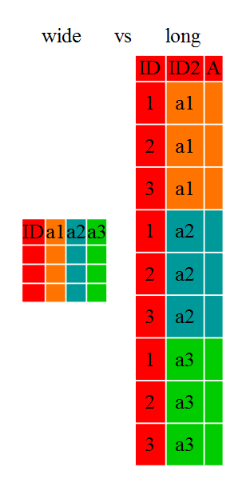

One way of thinking about it is that wide tables have a single ID column and then many value columns, whereas a long table has many ID columns and only a single value column. Coming from Excel, and base R, we are probably more familiar with wide tables, but the tidyverse really likes long tables. To switch between them, we use `pivot_longer()` and `pivot_wider()`.

Lets take a look at another very popular dataset, the `iris dataset`.

```r
iris %>% as_tibble()
```

```
## # A tibble: 150 × 5
##    Sepal.Length Sepal.Width Petal.Length Petal.Width Species
##           <dbl>       <dbl>        <dbl>       <dbl> <fct>
##  1          5.1         3.5          1.4         0.2 setosa
##  2          4.9         3            1.4         0.2 setosa
##  3          4.7         3.2          1.3         0.2 setosa
##  4          4.6         3.1          1.5         0.2 setosa
##  5          5           3.6          1.4         0.2 setosa
##  6          5.4         3.9          1.7         0.4 setosa
##  7          4.6         3.4          1.4         0.3 setosa
##  8          5           3.4          1.5         0.2 setosa
##  9          4.4         2.9          1.4         0.2 setosa
## 10          4.9         3.1          1.5         0.1 setosa
## # ℹ 140 more rows
```

> *Is the iris dataset long or wide?*
- The iris dataset is a typical wide dataset, where each trait is its own variable

```r
## lets reshape it!
iris %>%
  pivot_longer(-Species, names_to = "trait", values_to = "length")
```

```
## # A tibble: 600 × 3
##    Species trait        length
##    <fct>   <chr>         <dbl>
##  1 setosa  Sepal.Length    5.1
##  2 setosa  Sepal.Width     3.5
##  3 setosa  Petal.Length    1.4
##  4 setosa  Petal.Width     0.2
##  5 setosa  Sepal.Length    4.9
##  6 setosa  Sepal.Width     3
##  7 setosa  Petal.Length    1.4
##  8 setosa  Petal.Width     0.2
##  9 setosa  Sepal.Length    4.7
## 10 setosa  Sepal.Width     3.2
## # ℹ 590 more rows
```

Although this may seem trivial or even unnecessary at first glance, it is a hugely important data transformation technique, especially in combination with `group_by()` and facetting plots (more on that later).

### Visualizing data with ggplot2

#### 1. Create a new ggplot object

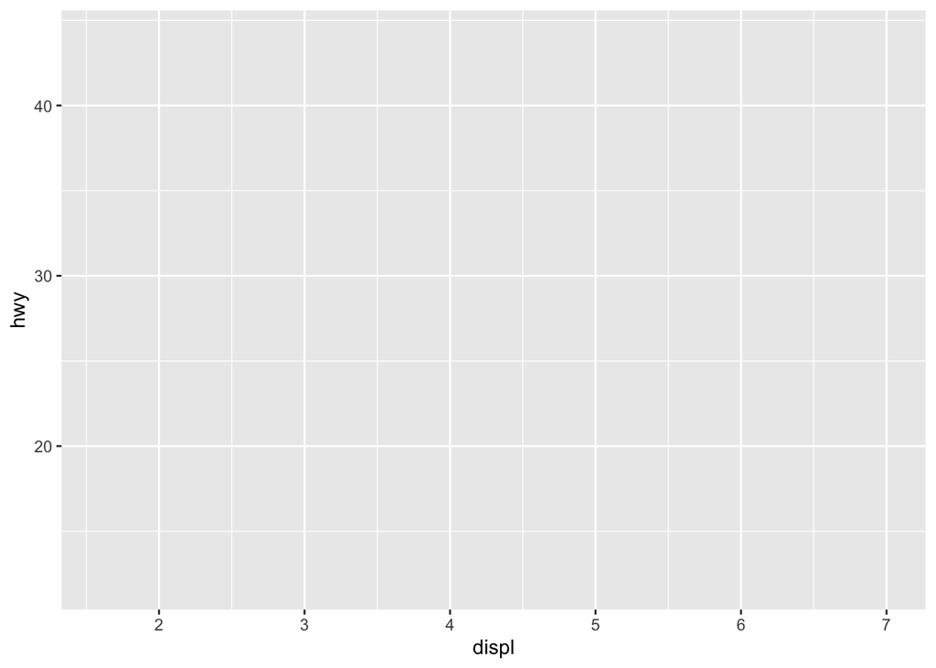

```r
# to build a plot we have to define two basic aspects
# 1. what is our dataset? - defined by  "data="
# 2. what variables do we want to plot? - defined by mapping the aesthetics, or "mapping=aes()"
ggplot(data=mpg,
       mapping=aes(x=displ, y=hwy))
```

#### 2. Add plot layers

Once the plot as been created, you can add any plot layer you like, using `geoms`. For example, the x and y data as points:

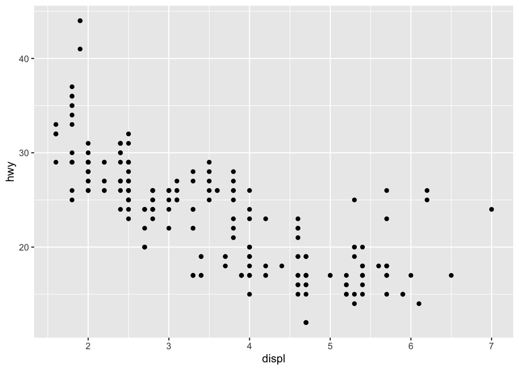

```r
ggplot(data=mpg,
       mapping=aes(x=displ, y=hwy)) +
  geom_point()
```

Different geoms allow for different data visualisation

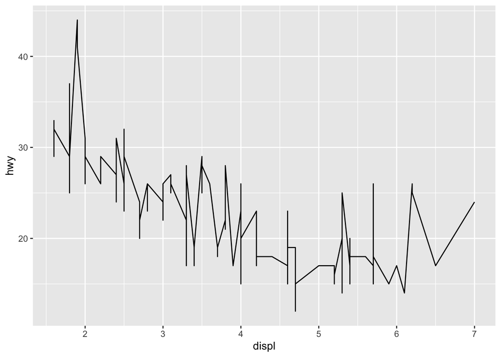

```r
# line graph
ggplot(data=mpg,
       mapping=aes(x=displ, y=hwy)) +
  geom_line()
```

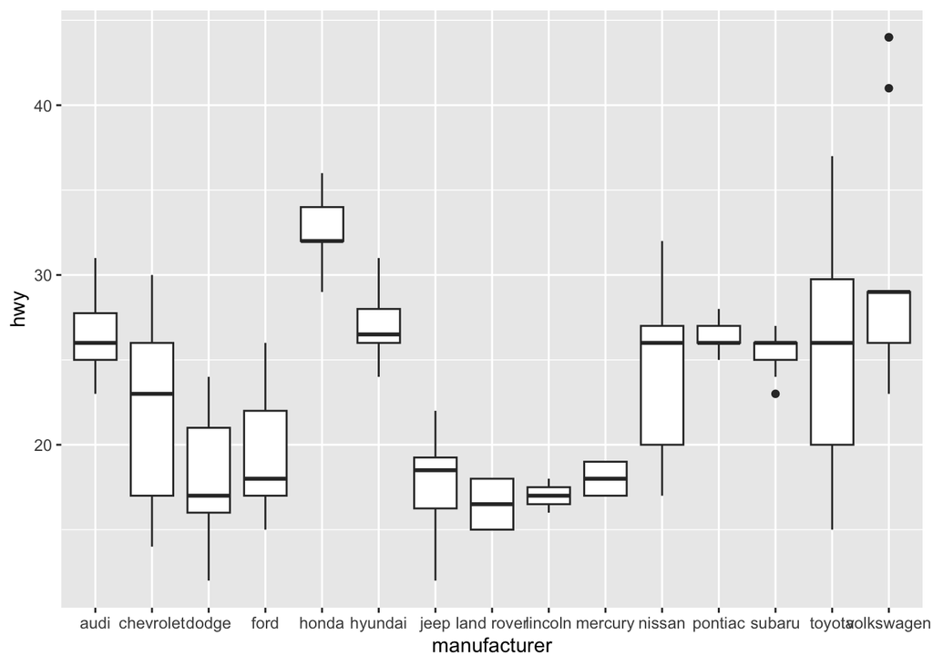

```r
# boxplot (categorical x axis)
ggplot(data=mpg,
       mapping=aes(x=manufacturer, y=hwy)) +
  geom_boxplot()
```

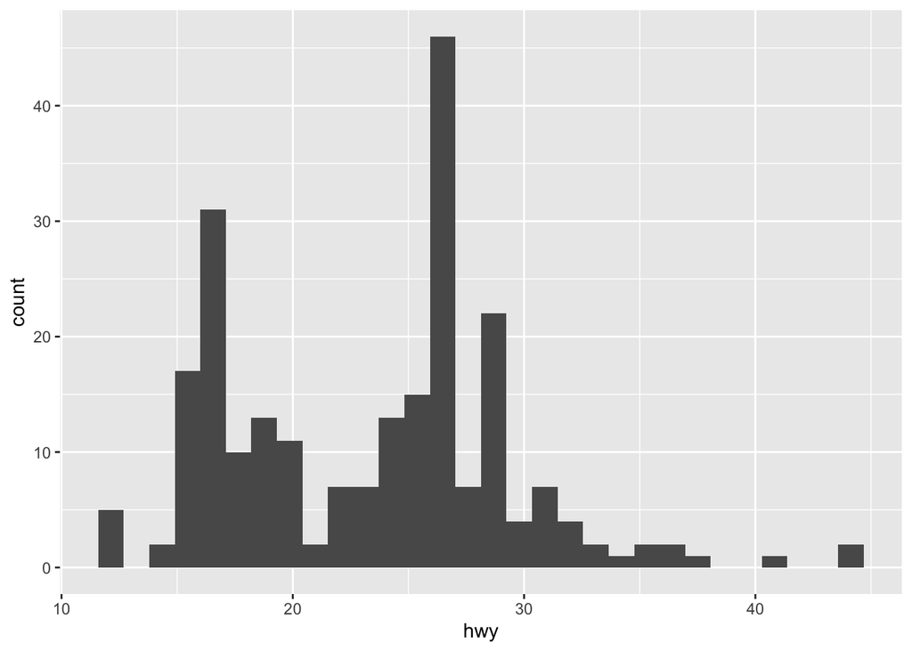

```r
# histogram
ggplot(data=mpg,
       mapping=aes(x=hwy)) +
  geom_histogram()
```

#### 3. Styling visualizations

Different styling can be added at different parts of the build.

Adding a fixed colour is done outside the aes()

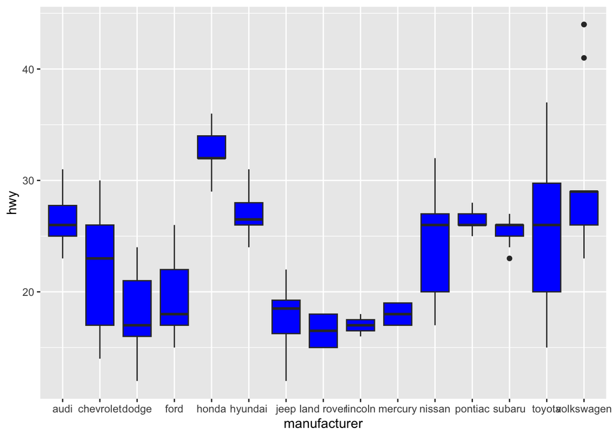

```r
ggplot(data=mpg,
       mapping=aes(x=manufacturer, y=hwy)) +
  geom_boxplot(fill="blue")
```

Adding a conditional colour is done insidee the aes()

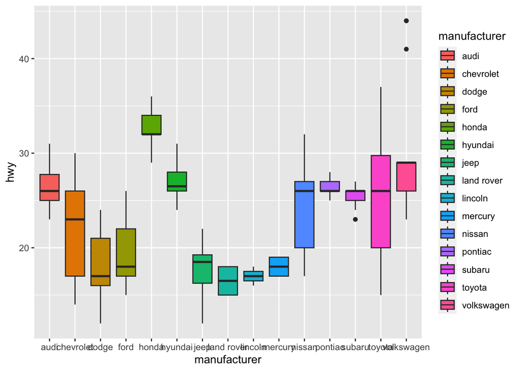

```r
ggplot(data=mpg,
       mapping=aes(x=manufacturer, y=hwy, fill=manufacturer)) +
  geom_boxplot()
```

General theme elements can be manipulated both with canned theme functions, or manually

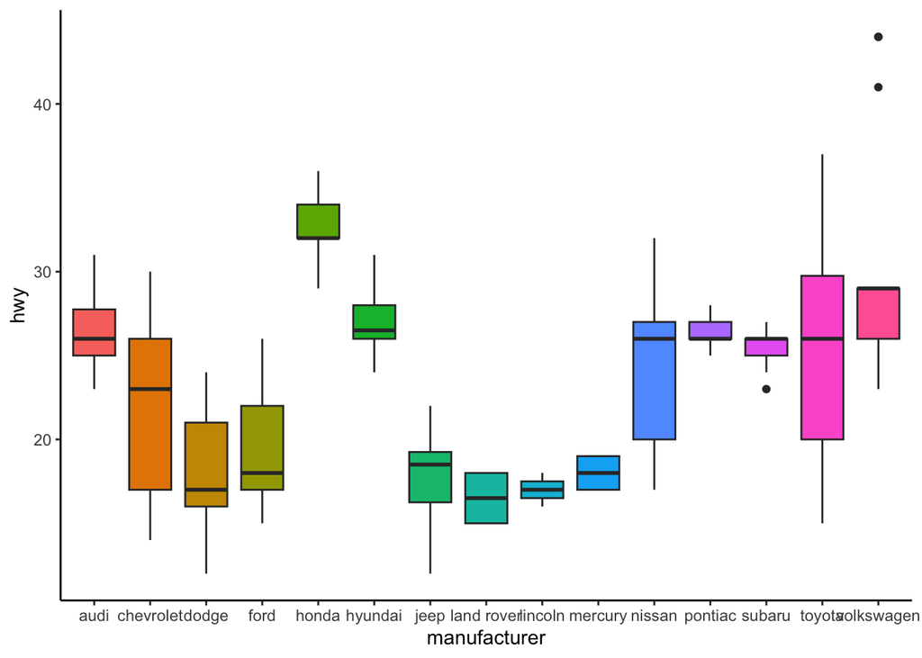

```r
ggplot(data=mpg,
       mapping=aes(x=manufacturer, y=hwy, fill=manufacturer)) +
  geom_boxplot() +
  ## apply a canned theme
  theme_classic() +
  ## edit the theme by e.g. removing the legend
  theme(legend.position = "none")
```

#### 4. Faceting

ggplot is great for organizing multiple plots for groups of data that share one or both axes. This is done with `facet_wrap()` of `facet_grid()`

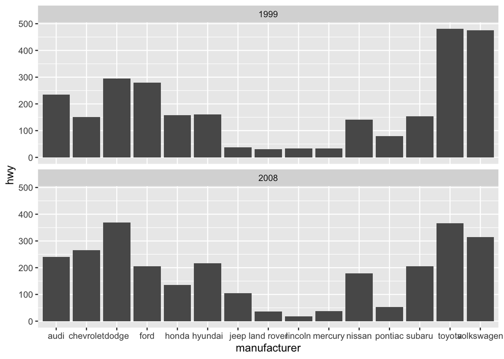

```r
# two plots that share the same x axis:
ggplot(data=mpg,
       mapping=aes(x=manufacturer, y=hwy)) +
  geom_bar(stat="identity") +
  facet_wrap(~year, ncol=1)
```

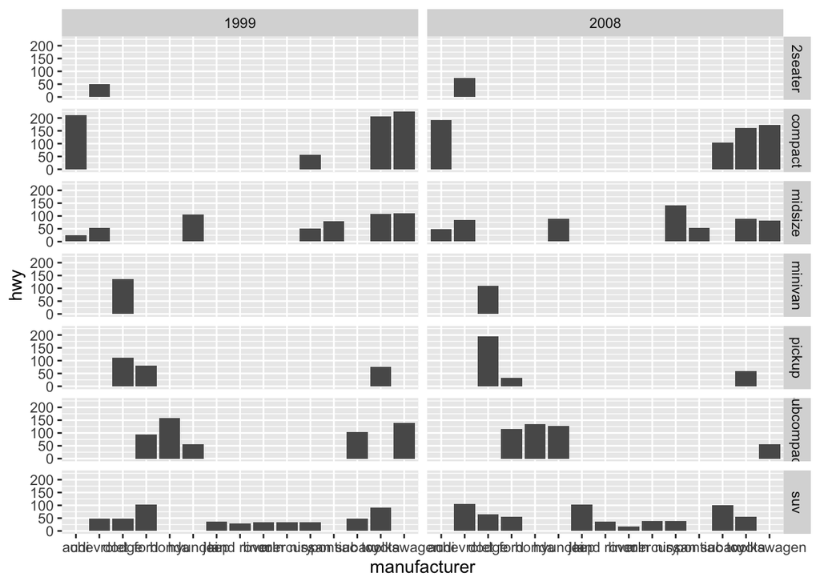

```r
# multiple plots that are grouped into two groups
ggplot(data=mpg,
       mapping=aes(x=manufacturer, y=hwy)) +
  geom_bar(stat="identity") +
  facet_grid(class~year)
```

### Final comments:

- Switching to the tidyverse can be a little daunting at first and may seem redundant. Many things can be done in base R. However, it is a powerful too for complex data organization and manipulation.
- Learn by doing! As with any programming language, the best way to learn is to just get your hands dirty. Your regular google search should be "how do i ________ using the tidyverse?".